# CA SWRB describe and fix missing data

Sandy Sum

2021-10-07

# Summary of monitoring data so far

### Individual PWS Arsenic monitoting data: Summary statistic

|  | N | Missing |  | Mean | SD |  | Min | Q1 | Median | Q3 | Max |
| --- | --- | --- | --- | --- | --- | --- | --- | --- | --- | --- | --- |
| freq | 6495 | 0 |  | 55.88 | 289.86 |  | 1 | 3 | 6.0 | 19.00 | 8587.00 |
| n_samplingloc | 6495 | 0 |  | 3.21 | 9.49 |  | 1 | 1 | 1.0 | 3.00 | 416.00 |
| mean_ar | 6495 | 0 |  | 4.18 | 6.31 |  | 0 | 1 | 2.1 | 4.53 | 40.04 |
| min_year | 6495 | 0 |  | 1999.72 | 9.30 |  | 1974 | 1992 | 2001.0 | 2006.00 | 2021.00 |
| max_year | 6495 | 0 |  | 2014.50 | 8.24 |  | 1977 | 2011 | 2019.0 | 2020.00 | 2021.00 |
| Population | 6490 | 5 |  | 6048.83 | 64321.01 |  | 0 | 40 | 102.5 | 400.00 | 4061504.00 |
| Connection | 6490 | 5 |  | 1406.99 | 12362.95 |  | 0 | 2 | 16.0 | 85.00 | 679740.00 |

Each PWS has from 1 to over 400 unique sampling point ID.

In my data, I am able to document if the sampling point correspond to a raw or treated source within a PWS.

[output not shown]

### How frequent does each PWS samples? Is it tied to Arsenic level?

- Frequency of sampling by each PWS is loosely tied to mean Arsenic level
- Not representative as some PWS might have many many connections or source, and hence is over represented if we just look at counts

Summarizing at the PWS-year level; no PWS is ever made to do a monthly sample so that would be ridiculous to try to summarize at the monthly level as I was previously doing.

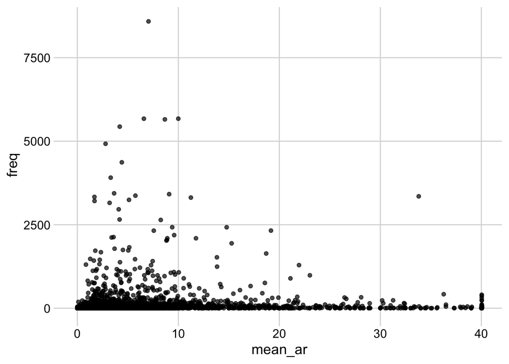

## Look at frequency of Ar monitoring by PWS

A lot does have annual data! I reckon I can get away with interpolating if gaps are less than 3 years apart.

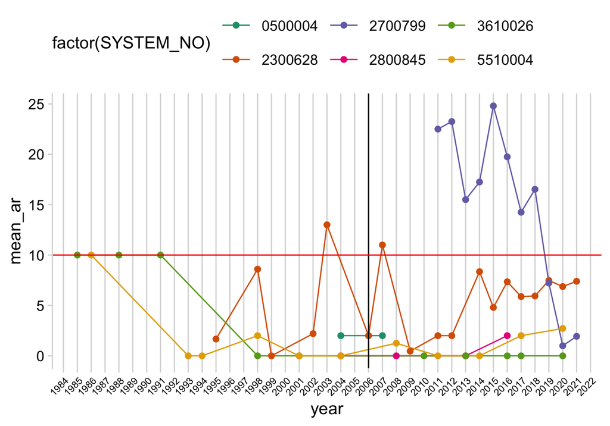

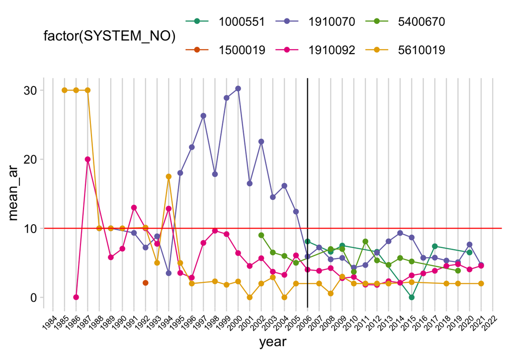

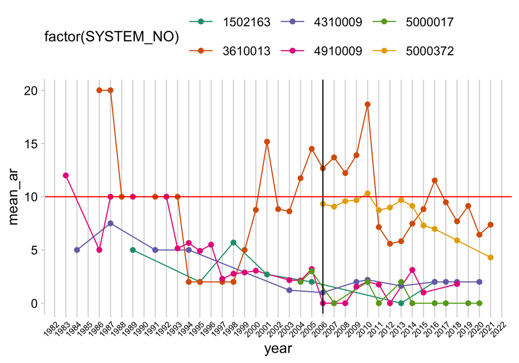

### Interpolation 1

Wow the spline would give very different values…

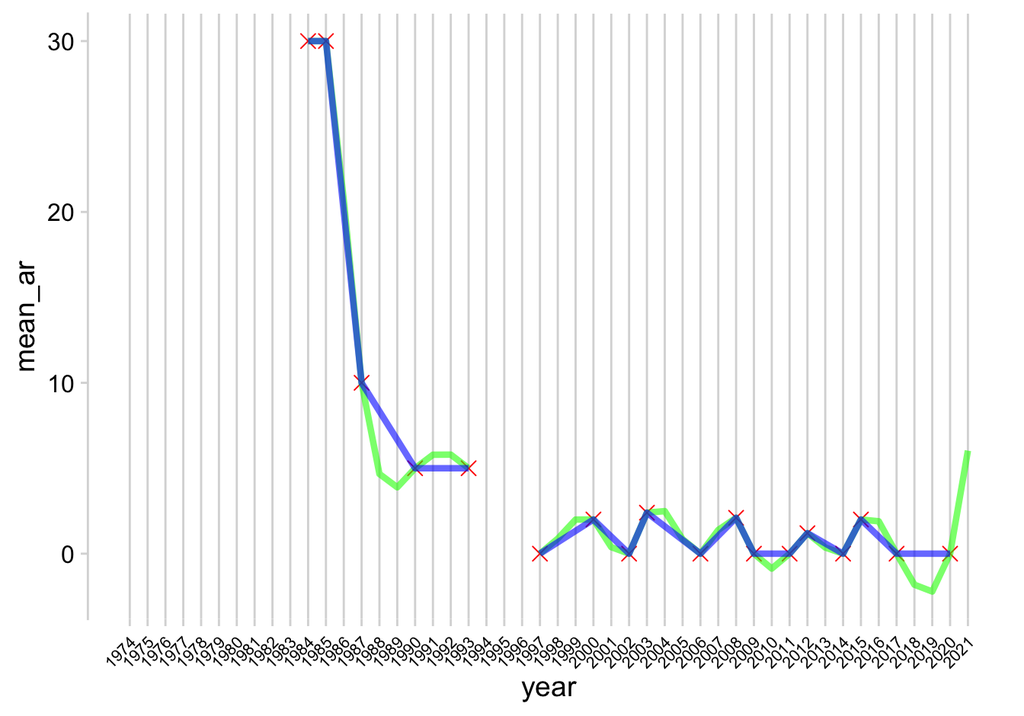

### Interpolation 2

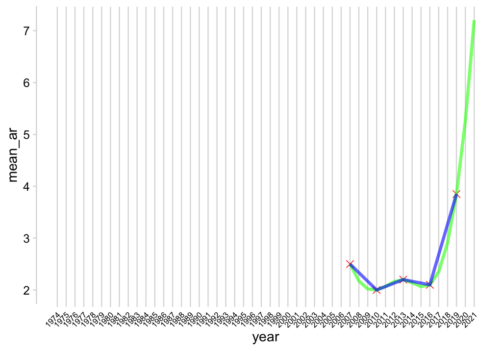

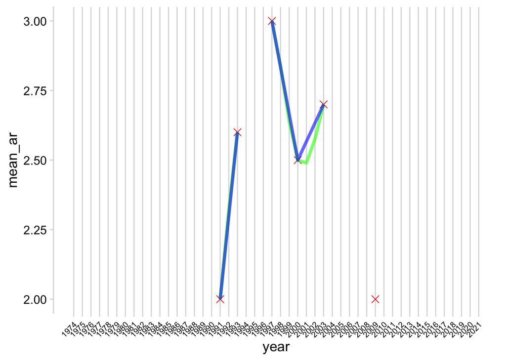